# Functional Programming

Nate Jones

02/2/2022

# 1.0 Primer

Functional programming is a style of programming that allows users to both create their own functions and execute those functions. Before the tidyverse take over of R, this was (and honestly still is) a way to improve the efficiency of your code. For more information, click [here](https://towardsdatascience.com/cleaner-r-code-with-functional-programming-adc37931ef7a).

For me (and for many others), I learned functional programming out of necessity! I was writing for-loops that were both slow and that were taking up too much RAM. Thus, I started creating functions to take advantage of parrallel processing, and the rest is history.

Below, you will find a brief tutorial on writing functions, a fun #dadjoke snippet, and finally a list of best practices.

# 2.0 Tutorial

The goal of this tutorial is to demonstrate a workflow that estimates annual metrics from USGS streamflow data. Users are expected to have working knowledge of both R and tidyverse.

## 2.1 Workflow: Estimating annual runoff

In the past few years, my team has used USGS gage data to investigate [river-floodplain connectivity](https://doi.org/10.1038/s41467-019-13184-4), [drying regimes of non-perinial streams](https://doi.org/10.1029/2021GL093298), and [changes in those drying regimes](https://doi.org/10.1088/1748-9326/ac14ec). To mirror those analyses, lets create a function to download USGS stream gage data and estimate annual runoff. (Note, check out [this tutorial on the dataRetrieval package](https://waterdata.usgs.gov/blog/dataretrieval/) for more information on downloading USGS gage data!)

Below is a workflow we could use to estimate annual runoff for one gage:

```r
#Load libraries of interest
library(dataRetrieval)
library(tidyverse)
library(lubridate)

#Define gage number of interest
gage<-'02446500'

#download flow data (cfs)
df<-readNWISdv(
  siteNumbers = gage,
  parameterCd = '00060'
)

#Download watershed area (mi^2)
ws_area<-readNWISsite(siteNumbers = gage) %>% select(drain_area_va) %>% pull()

#Tidy data frame and estimate annual runoff
df<-df %>%
  #convert to tibble
  as_tibble %>%
  #Select and rename cols of interest
  select(
    date = Date,
    Q_cfs=X_00060_00003) %>%
  #convert date col to lubridate format
  mutate(date=ymd(date)) %>%
  #Estimate daily runoff depth
  mutate(q_in_day = Q_cfs/ws_area/(5280^2)*(12)*86400) %>%
  #Summarise runoff by year
  mutate(year = year(date)) %>%
  group_by(year) %>%
  summarise(
    q_in = sum(q_in_day, na.rm=T),
    n = n()) %>%
  #filter years with less than 350 days of data
  filter(n>350) %>%
  select(-n)
```

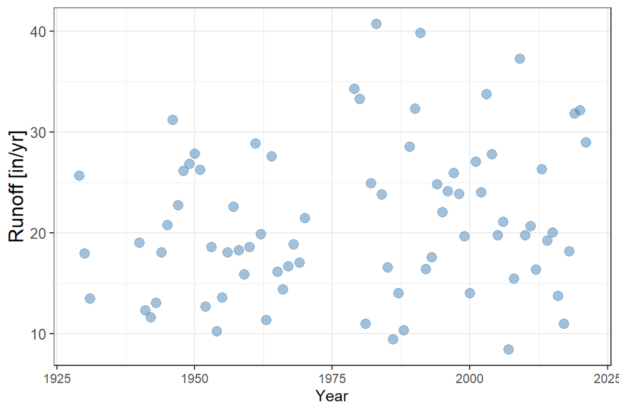

## 2.2 Creating the function

Now, we want to run this for several gages! You have a few different options: (i) hire an army of undergrads, (ii) start ‘copy/paste’ manual labor, (iii) create a function! Let’s try the latter.

Notably, we use the following notation to create a function in R:

```r
name<-function(variable){
  CODE
}
```

where *name* is the name of the function, *variable* is the variable you use to run the function, and *CODE* is the code you want to apply to the variable in question.

Below we convert the workflow presented above into a function:

```r
#Create function to estimate average annual runoff
fun<-function(gage){
  #Load libraries of interest
  library(dataRetrieval)
  library(tidyverse)
  library(lubridate)

  #download flow data (cfs)
  df<-readNWISdv(
    siteNumbers = gage,
    parameterCd = '00060'
  )

  #Download watershed area (mi^2)
  ws_area<-readNWISsite(siteNumbers = gage) %>% select(drain_area_va) %>% pull()

  #Tidy data frame and estimate annual runoff
  df<-df %>%
    #convert to tibble
    as_tibble %>%
    #Select and rename cols of interest
    select(
      date = Date,
      Q_cfs=X_00060_00003) %>%
    #convert date col to lubridate format
    mutate(date=ymd(date)) %>%
    #Estimate daily runoff depth
    mutate(q_in_day = Q_cfs/ws_area/(5280^2)*(12)*86400) %>%
    #Summarise runoff by year
    mutate(year = year(date)) %>%
    group_by(year) %>%
    summarise(
      q_in = sum(q_in_day, na.rm=T),
      n = n()
    ) %>%
    #filter years with less than 350 days of data
    filter(n>350) %>%
    select(-n) %>%
    #estimate annual runoff
    summarise(
      q_in = mean(q_in)
    )

  #Prepare export
  df<-df %>% mutate(gage = gage)

  #Export data
  df
}

#test function
fun('02446500')
```

Scroll down to the best practices section for more information on the construction of this function. Notably, we (i) loaded our required packages within the function, (ii) kept the global and functional environments separate, and (iii) exported a single roww of data from the function.

## 2.3 Applying the function

Now that we have a working function, how do we use it? My favorite approach is to employ the *lapply()* and *bind_rows()* functions in series. Note, it’s also sometimes useful to create a wrapper function so you can use a counter. This work flow could looks something like:

```r
#Create a list ogages (Mississippi River, Alabama River, and Potomac River gages)
gages<- c("07374000", "02428400", "01646500")

#Create wrapper function
wrapper_fun<-function(n){fun(gages[n])}

#Now run function
output<-lapply(
  X=seq(1, length(gages)),
  FUN=wrapper_fun
)

#Now, bind rows from list output
output<-output %>% bind_rows()
```

## 2.4 Error Handling

OK, now that we can apply the function, its important to think about building robust code so you you can apply it to large datasets without errors. You can do this by both cleaning your input data AND using an error catching function. Below is how I usually build error functions:

```r
#Create a list gages (Note, we Mobile River gage that does not record flow)
gages<- c("02470630","07374000", "02428400", "01646500")

#Create wrapper function
error_fun<-function(n){
  tryCatch(
    expr = fun(gages[n]),
    error = function(e)
      tibble(
        q_in=-9999,
        gage = gages[n])
      )
}


#Now run function
output<-lapply(
  X=seq(1, length(gages)),
  FUN=error_fun
)

#Now, bind rows from list output
output<-output %>% bind_rows()
```

## 2.4 Paralell processing

Now that you’ve got some robust code built, you can apply it to a large dataset! To do this, you may find it advantageous to send your function to multiple cores. Below we use the parallel library to estimate annual mean runoff from all the gages accross Alabama!

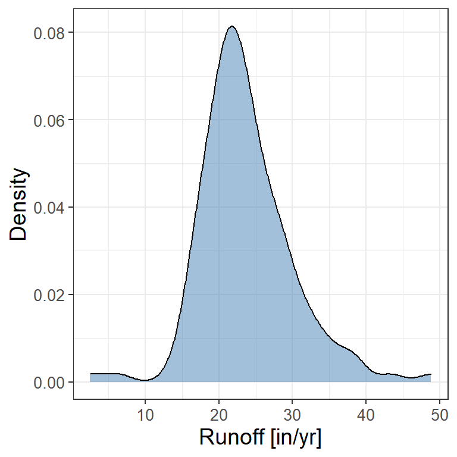

```r
#Load the parallel package
library(parallel)

#Create list of all gages in Alabama
gages<- c("02339495","02342500","02342937","02342997","023432415","02361000","02361500","02362000","02362240","02363000","02364000","02364500","02369800","02371500","02372250","02372422","02372430","02373000","02374050","02374250","02374500","02374700","02374745","02374950","02375000","02377560","02377570","02377750","02378170","02378185","02378300","02378500","0237854520","02378780","02378790","02397530","02398300","02399200","02399500","02399600","02400100","02400175","02400496","02400500","02400680","02401000","02401330","02401390","02401895","02403310","02404400","02405500","02406500","02406930","02407000","02407514","02407526","02408150","02408540","02411590","02411600","02412000","02413300","02414300","02414500","02414715","02415000","02416360","02418230","02418760","02419000","02419500","02419890","02419988","02420000","02421000","02421350","02421351","02422500","02423000","02423110","02423130","02423160","02423380","02423397","02423400","02423414","02423425","02423496","02423500","0242354650","0242354750","02423555","02423571","02423586","02423630","02423647","02424000","02424590","02425000","02427250","02427505","02427506","02428400","02428401","02429540","02438000","02444160","02444161","02446500","02447025","02447026","02448500","02448900","02449838","02449882","02450180","02450250","02450825","02453000","02453500","02454000","02454055","02455000","02455185","02455980","02456000","02456500","02457595","02457704","02458148","02458190","02458300","02458450","02458502","02458600","02460500","02461130","02461192","02461405","02461500","02462000","02462500","02462501","02462951","02462952","02464000","02464800","02465000","02465005","02465292","02465493","02466030","02466031","02467000","02467001","02467500","02469500","02469525","02469761","02469762","02469800","02470050","02470072","02470629","02470630","02471001","02471019","02471078","02479500","02479945","02479980","02480002","02480020","03572110","03572690","03572900","03574100","03574500","03574768","0357479650","03574975","03575100","0357526200","03575272","0357568650","0357568980","03575700","03575830","0357586650","0357587090","0357587140","0357587400","0357587728","03575890","0357591500","03575950","03575980","03576148","03576250","03576500","03577225","03586500","03590000","03592000","03592500")

#Determine number of processing cores available on your machine
n.cores<-detectCores()-1

#Create clusters
cl<-makeCluster(n.cores)

#Send libraries to cluster
clusterEvalQ(cl, {
  library(dataRetrieval)
  library(tidyverse)
  library(lubridate)
   })

#Export data to cluter environments
clusterExport(cl, c("fun", "gages"))

#Now run function
output<-parLapply(
  cl=cl,
  seq(1, length(gages)),
  error_fun)

#Now, bind rows from list output
output<-output %>% bind_rows()

#Stop the clusters
stopCluster(cl)
```

# 3.0 Check your understanding

Now that you can build a function – create a tibble containing 10 ‘Dad’ jokes using the *dadjokeapi* package and *groan()* function.

**Toggle answer**

```r
  #load library
  library(dadjokeapi)

  #Create function
  fun<-function(n){
    #retreave dad joke
    joke<-groan()

    #Create output
    tibble(
      n,
      joke = joke$joke
    )
  }

  #apply function
  output<-lapply(seq(1,10), fun) %>% bind_rows()
```

# 4.0 Best Practices

Here are some helpful hints I typically employ in my coding:

**1. Keep your global environment and your function’s environment completely separate!** Its temping to use a function that edits a data frame or tibble in your global environment. However, this can lead to mass confusion, gnashing of teath, and general pain and suffering. Just don’t do it.

**2. Load packages you need in your function**. Yes, you can pass packages between your global environment and your functional environment. However, if/when you graduate to parallel processing, this is no longer an option. Just eat your damn veggies and do this! Its easy to just list the required packages at the start of your function!

**3. Use a counter as your variable**. This is more of a suggestion. However, using a counter (i.e., similar to integers employed in for-loops) can simplify your workflow both when initiating your function and joining the results after the function is complete.

**4. Export your results from function as a single row with unique ID.** Once you run your function, its imperative to transfer the results from the functional environment to the global environment. Exporting this information as a row of data with unique ID will allow you to join it to your master dataframe!

**5. Create a wrapper function to handle errors.** See the example above. Using an error function can save you a ton of frustration…especially when your using your function to complete hundreds to tens of thousands of tasks!